# Titer Response Analysis

Marco Kreuzer

IBU  
marco.kreuzer@unibe.ch

19.05.2025

## Background

When evaluating vaccine-induced immune responses, a common approach is to compute the **fold change** in antibody titers from baseline to outcome. However, fold changes are **biased by baseline titers** — individuals with high baseline titers typically show lower relative increases (and vice versa). This confounding effect complicates comparisons between individuals.

To correct for this, the following strategies were used:

1. Classification based on linear model with max response titer.
2. Classification based on linear model with sum response titer (the corrected fold change was summed up across all strains)
3. A dense ranking approach of the summed titers
4. . **Method 1 (Beyer et al.)**: Adjust the *outcome titers* via linear regression to a common baseline, then compute fold changes.

## Data Transformation

```r
df <- read.csv("titer_data.csv")

# Pivot longer to isolate strain + metric info
df_long <- df %>%
  pivot_longer(
    cols = starts_with("hai_") | starts_with("microneut_"),
    names_to = "key",
    values_to = "value"
  ) %>%
  mutate(
    measurement = case_when(
      str_starts(key, "hai_") ~ "hai",
      str_starts(key, "microneut_") ~ "microneut"
    ),
    strain = str_extract(key, "(H1N1|H3N2|BVic|BYam)"),
    metric = case_when(
      str_detect(key, "ic50") ~ "ic50",
      TRUE ~ "titer"
    )
  ) %>%
  select(Pat_ID, pat_group, Titer_type, strain, measurement, metric, value)

# Pivot wider based on Titer_type (baseline/outcome).
df_wide <- df_long %>%
  pivot_wider(
    names_from = Titer_type,
    values_from = value
  ) %>%
  rename(
    baseline = baseline_titer,
    outcome = outcome_titer
  )

# Calculate fold change and standardize. Note that standardisation is done within measurement, strain and metric
df_fc <- df_wide %>%
  mutate(
    fold_change = outcome / baseline
  ) %>%
  group_by(measurement, strain, metric) %>%
  mutate(
    fc_std_norm = (fold_change - median(fold_change, na.rm = TRUE)) / sd(fold_change, na.rm = TRUE),
    baseline_std_norm = (baseline - median(baseline, na.rm = TRUE)) / sd(baseline, na.rm = TRUE)
  ) %>%
  ungroup()
```

## Data Exploration

### Missing Data Check

To ensure analysis quality, patients with missing HAI baseline or outcome values were identified and excluded. Check whether baseline and outcome values for HAI are present for all patients.

```r
to_exclude <- df_fc %>%
  filter(measurement == "hai") %>%
  filter(is.na(baseline) | is.na(outcome) | !is.finite(baseline) | !is.finite(outcome)) %>%
  pull(Pat_ID) %>%  unique()
print(to_exclude)
```

```
## [1] "FluV_CO_041"  "FluV_HIV_027" "FluV_MS_024"
```

Three patients lacked valid outcome titers and were removed:

```r
df_fc <- df_fc %>%
  filter(!Pat_ID %in% to_exclude)
```

### Raw Titer Evaluation

**Baseline versus Outcome Titer**

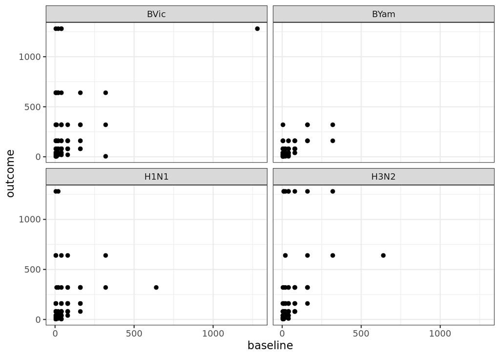

```r
df_fc %>%
  filter(measurement == "hai") %>%
  ggplot(aes(x=baseline, y=outcome)) +
  geom_point() +
  facet_wrap(~strain) +
  theme_bw()
```

Some patients show decreased titers post-vaccination. This may reflect natural titer waning, technical artifacts, or biological non-response. For example, patient FluV_ONK_006 exhibited lower post-vaccine titers than baseline.

### Fold Change Visualization

**Raw Fold Change**

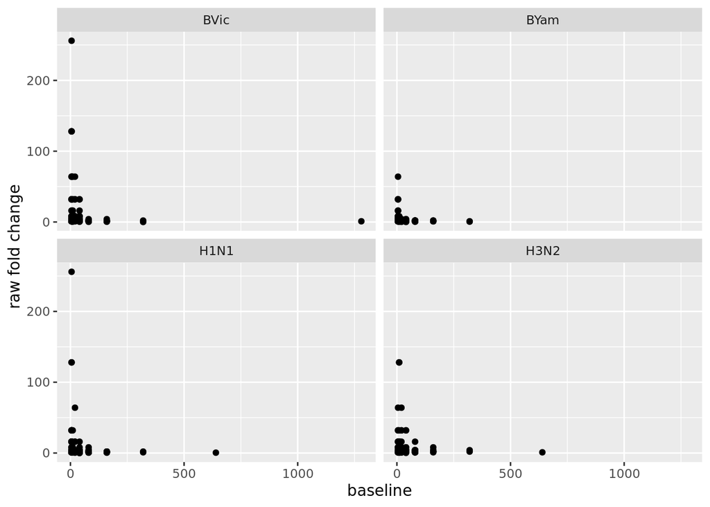

```r
df_fc %>%
  filter(measurement == "hai") %>%
  ggplot(aes(x=baseline, y=fold_change)) +
  geom_point() +
  facet_wrap(~strain) +
  ylab("raw fold change")
```

**Standardized Fold Change**

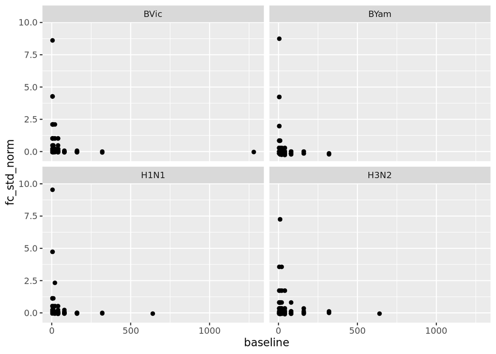

```r
df_fc %>%
  filter(measurement == "hai") %>%
  ggplot(aes(x=baseline, y=fc_std_norm)) +
  geom_point() +
  facet_wrap(~strain)
```

### Correlation of Fold Changes Between Strains

To explore cross-strain response consistency, the standardized fold change correlations were computed.

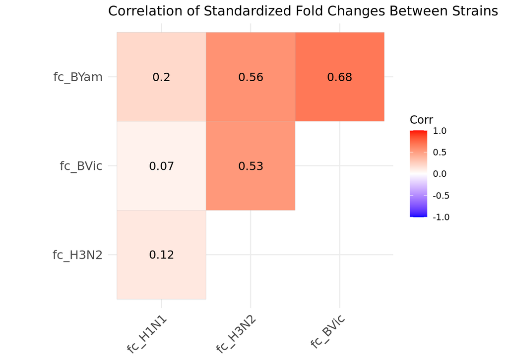

```r
df_fc_wide <- df_fc %>%
  filter(measurement == "hai", metric == "titer") %>%
  select(Pat_ID, strain, fc_std_norm)  %>%
  pivot_wider(names_from = strain, values_from = fc_std_norm, names_prefix = "fc_")

cor_matrix <- df_fc_wide %>%
  select(starts_with("fc_")) %>%
  cor(use = "pairwise.complete.obs")

ggcorrplot(cor_matrix,
           type = "upper",
           lab = TRUE,
           title = "Correlation of Standardized Fold Changes Between Strains")
```

## Classification based on linear model with max response titer

To identify vaccine responders, we used a standardized fold change approach based on each individual’s strongest antibody response.

The residuals from this model (referred to as *padjMFC*) represent how much stronger or weaker a patient’s response was compared to others with similar baseline titers.

4. **Responder Classification**

Patients were classified based on either 20 or 30 % quantiles.

- **High responders**: Top 20 or top 30% of patients
- **Moderate responders**: Middle range
- **Low responders**: Bottom 20 or bottom 30% of patients

This approach adjusts for baseline immunity and highlights individuals with unusually strong or weak vaccine responses.

```r
df_responder <- df_fc %>%
  filter(measurement == "hai", metric == "titer") %>%
  group_by(Pat_ID) %>%
  mutate(
    fc_norm_max_ivt = max(fc_std_norm, na.rm = TRUE),
    d0_norm_paired = baseline_std_norm[which.max(fc_std_norm)]
  ) %>%
  slice_max(fc_std_norm, n = 1, with_ties = FALSE) %>%
  ungroup()

model <- lm(fc_norm_max_ivt ~ d0_norm_paired, data = df_responder)

df_responder <- df_responder %>%
  mutate(padjMFC = augment(model, data = .)$`.resid`)

discretize <- c(0.2, 0.3)
responseLabels <- c("lowResponder", "moderateResponder", "highResponder")

for (dis in discretize) {
  q_low <- quantile(df_responder$padjMFC, dis, na.rm = TRUE)
  q_high <- quantile(df_responder$padjMFC, 1 - dis, na.rm = TRUE)

  df_responder <- df_responder %>%
    mutate(!!paste0("padjMFC_d", dis * 100) := factor(case_when(
      is.na(padjMFC) ~ NA_character_,
      padjMFC <= q_low ~ responseLabels[1],
      padjMFC >= q_high ~ responseLabels[3],
      TRUE ~ responseLabels[2]
    ), levels = responseLabels))
}
```

### Visualizations

**Visualization of Adjusted Fold Change Distribution**

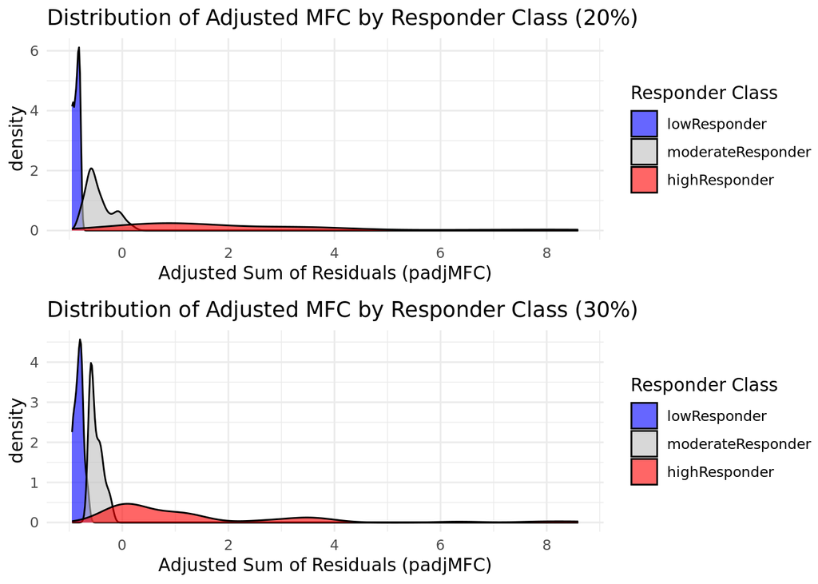

```r
g1 <- ggplot(df_responder, aes(x = padjMFC, fill = padjMFC_d20)) +
  geom_density(alpha = 0.6) +
  scale_fill_manual(values = c("blue", "gray", "red")) +
  labs(title = "Distribution of Adjusted MFC by Responder Class (20%)",
       x = "Adjusted Sum of Residuals (padjMFC)", fill = "Responder Class") +
  theme_minimal()

g2 <- ggplot(df_responder, aes(x = padjMFC, fill = padjMFC_d30)) +
  geom_density(alpha = 0.6) +
  scale_fill_manual(values = c("blue", "gray", "red")) +
  labs(title = "Distribution of Adjusted MFC by Responder Class (30%)",
       x = "Adjusted Sum of Residuals (padjMFC)", fill = "Responder Class") +
  theme_minimal()

cowplot::plot_grid(g1,g2,nrow = 2)
```

**Boxplots by Response Category**

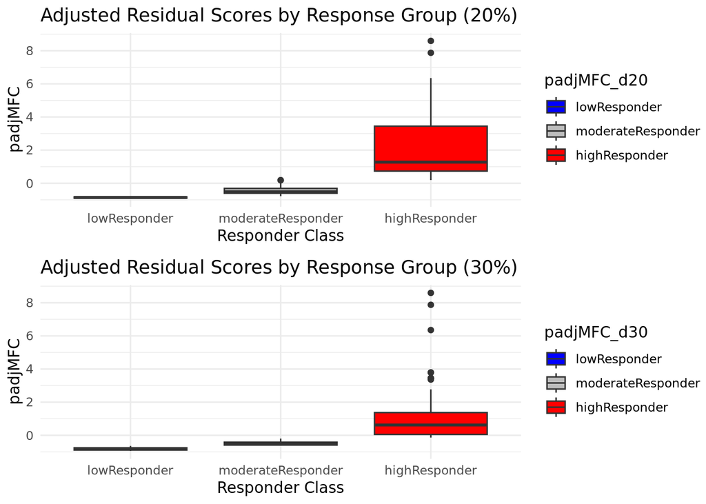

```r
g1 <- ggplot(df_responder, aes(x = padjMFC_d20, y = padjMFC, fill = padjMFC_d20)) +
  geom_boxplot() +
  labs(title = "Adjusted Residual Scores by Response Group (20%)",
       x = "Responder Class", y = "padjMFC") +
  scale_fill_manual(values = c("blue", "gray", "red")) +
  theme_minimal()

g2 <- ggplot(df_responder, aes(x = padjMFC_d30, y = padjMFC, fill = padjMFC_d30)) +
  geom_boxplot() +
  labs(title = "Adjusted Residual Scores by Response Group (30%)",
       x = "Responder Class", y = "padjMFC") +
  scale_fill_manual(values = c("blue", "gray", "red")) +
  theme_minimal()

cowplot::plot_grid(g1,g2,nrow = 2)
```

**Baseline vs. Standardized Fold Change by Responder Class**

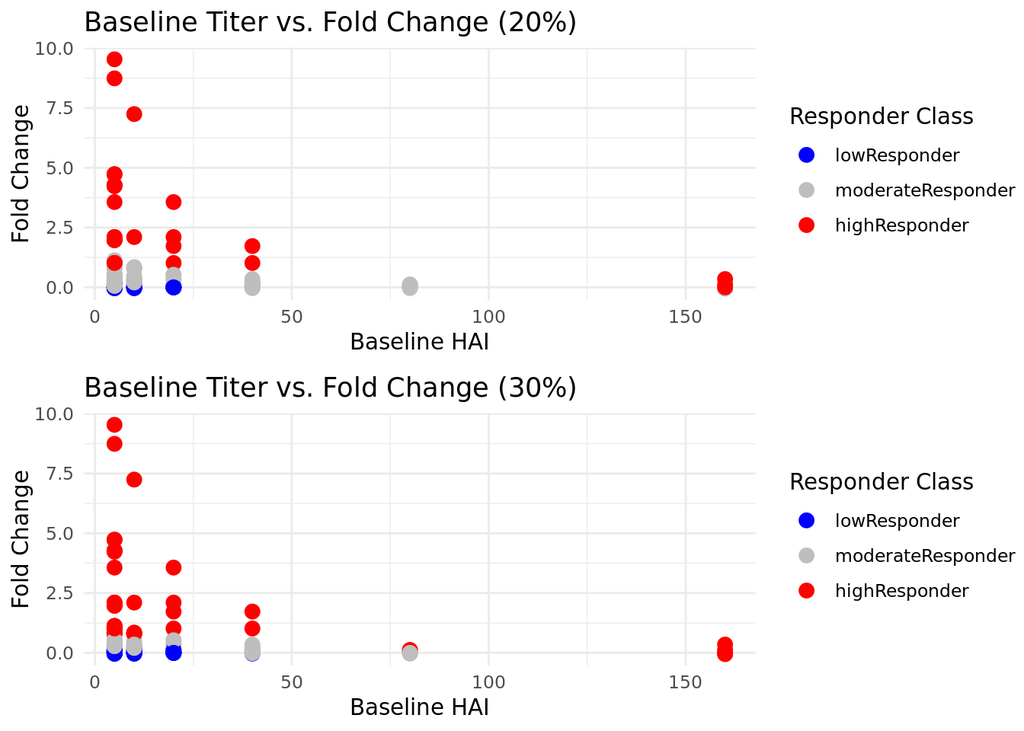

```r
g1 <- ggplot(df_responder, aes(x = baseline, y = fc_std_norm, color = padjMFC_d20)) +
  geom_point(size = 3) +
  scale_color_manual(values = c("blue", "gray", "red")) +
  labs(title = "Baseline Titer vs. Fold Change (20%)",
       x = "Baseline HAI", y = "Fold Change",
       color = "Responder Class") +
  theme_minimal()


g2 <- ggplot(df_responder, aes(x = baseline, y = fc_std_norm, color = padjMFC_d30)) +
  geom_point(size = 3) +
  scale_color_manual(values = c("blue", "gray", "red")) +
  labs(title = "Baseline Titer vs. Fold Change (30%)",
       x = "Baseline HAI", y = "Fold Change",
       color = "Responder Class") +
  theme_minimal()

cowplot::plot_grid(g1,g2,nrow = 2)
```

## Classification Based on Linear Model with Sums of the Response Titers

To capture the **overall vaccine response** across all HAI strains per individual, we implemented a **sum-based approach**. This method provides a comprehensive view by integrating fold change responses across strains rather than focusing on a single maximum value.

### Methodology

- **Summation of Fold Changes**  
  For each patient, standardized fold changes (`fc_std_norm`) were summed across all HAI strains. Similarly, the standardized baseline titers were also summed. This produced a patient-level summary of total vaccine-induced responsiveness and pre-existing immunity.
- **Linear Model Adjustment**  
  A linear model was fitted to adjust for the confounding effect of cumulative baseline titers:

  $$\text{Sum of Standardized Fold Changes} \sim \text{Sum of Standardized
  Baseline Titers}$$

  The model residuals (`padjMFC`) quantify how much stronger or weaker a patient’s overall response was compared to what would be expected given their baseline immunity.
- **Responder Classification**  
  As in the previous section, patients were classified using quantiles of the residual distribution:
  - **High responders**: Top 20% / 30% of adjusted residuals
  - **Low responders**: Bottom 20% / 30%
  - **Moderate responders**: Remaining individuals

  This quantile-based classification helps highlight individuals with unusually strong or weak global responses, while accounting for baseline variation.

```r
df_responder_sum <- df_fc %>%
  filter(measurement == "hai", metric == "titer") %>%
  group_by(Pat_ID) %>%
  summarise(
    pat_group = first(pat_group),
    fc_norm_sum_ivt = sum(fc_std_norm, na.rm = TRUE),
    d0_norm_sum = sum(baseline_std_norm, na.rm = TRUE),
    .groups = "drop"
  )

model_sum <- lm(fc_norm_sum_ivt ~ d0_norm_sum, data = df_responder_sum)

df_responder_sum <- df_responder_sum %>%
  mutate(padjMFC = augment(model_sum, data = .)$`.resid`)

discretize <- c(0.2, 0.3)
responseLabels <- c("lowResponder", "moderateResponder", "highResponder")

for (dis in discretize) {
  q_low <- quantile(df_responder_sum$padjMFC, dis, na.rm = TRUE)
  q_high <- quantile(df_responder_sum$padjMFC, 1 - dis, na.rm = TRUE)

  df_responder_sum <- df_responder_sum %>%
    mutate(!!paste0("padjMFC_d", dis * 100) := factor(case_when(
      is.na(padjMFC) ~ NA_character_,
      padjMFC <= q_low ~ responseLabels[1],
      padjMFC >= q_high ~ responseLabels[3],
      TRUE ~ responseLabels[2]
    ), levels = responseLabels))
}
```

### Visualizations

**Visualization of Adjusted Residual Distributions**

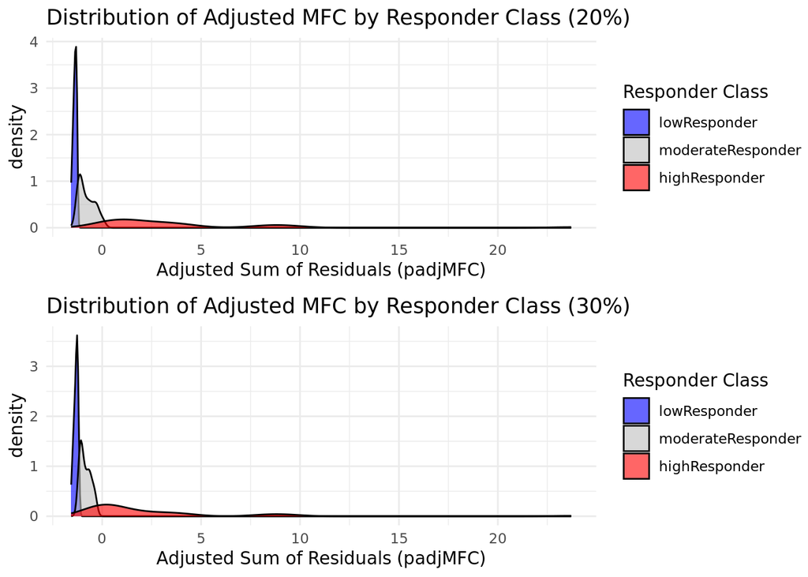

```r
g1 <- ggplot(df_responder_sum, aes(x = padjMFC, fill = padjMFC_d20)) +
  geom_density(alpha = 0.6) +
  scale_fill_manual(values = c("blue", "gray", "red")) +
  labs(title = "Distribution of Adjusted MFC by Responder Class (20%)",
       x = "Adjusted Sum of Residuals (padjMFC)", fill = "Responder Class") +
  theme_minimal()

g2 <- ggplot(df_responder_sum, aes(x = padjMFC, fill = padjMFC_d30)) +
  geom_density(alpha = 0.6) +
  scale_fill_manual(values = c("blue", "gray", "red")) +
  labs(title = "Distribution of Adjusted MFC by Responder Class (30%)",
       x = "Adjusted Sum of Residuals (padjMFC)", fill = "Responder Class") +
  theme_minimal()

cowplot::plot_grid(g1,g2,nrow = 2)
```

**Boxplots by Responder Class**

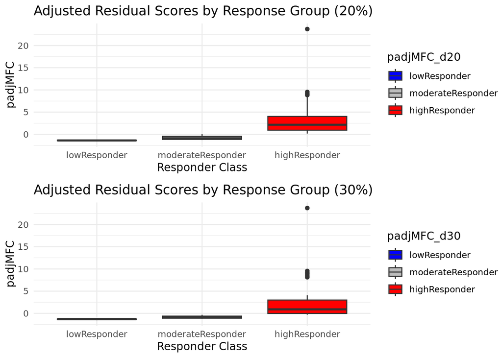

```r
g1 <- ggplot(df_responder_sum, aes(x = padjMFC_d20, y = padjMFC, fill = padjMFC_d20)) +
  geom_boxplot() +
  labs(title = "Adjusted Residual Scores by Response Group (20%)",
       x = "Responder Class", y = "padjMFC") +
  scale_fill_manual(values = c("blue", "gray", "red")) +
  theme_minimal()

g2 <- ggplot(df_responder_sum, aes(x = padjMFC_d30, y = padjMFC, fill = padjMFC_d30)) +
  geom_boxplot() +
  labs(title = "Adjusted Residual Scores by Response Group (30%)",
       x = "Responder Class", y = "padjMFC") +
  scale_fill_manual(values = c("blue", "gray", "red")) +
  theme_minimal()

cowplot::plot_grid(g1,g2,nrow = 2)
```

**Sum of Baseline Titers vs Sum of Fold Change**

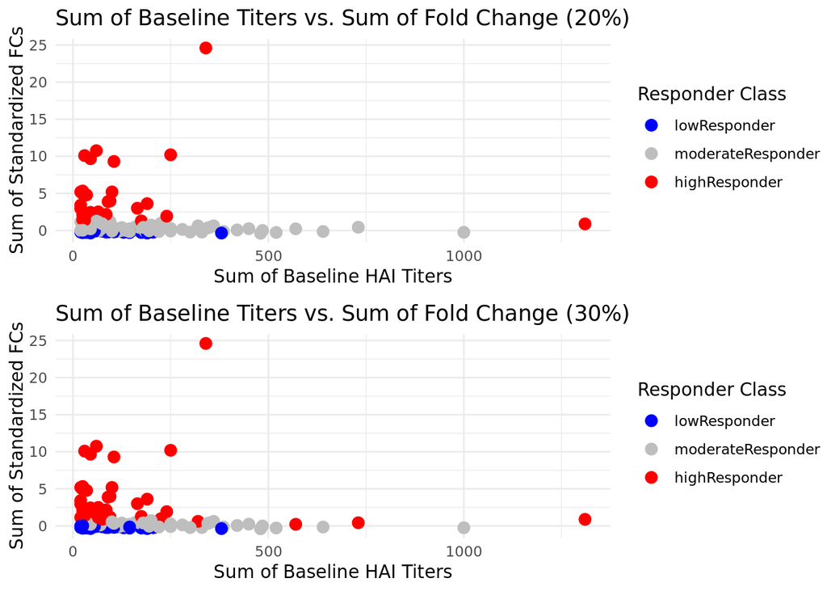

```r
df_responder_plot <- df_fc %>%
  filter(measurement == "hai", metric == "titer") %>%
  group_by(Pat_ID) %>%
  summarise(
    baseline_sum = sum(baseline, na.rm = TRUE),
    fc_std_norm_sum = sum(fc_std_norm, na.rm = TRUE),
    .groups = "drop"
  ) %>%
  left_join(df_responder_sum, by = "Pat_ID")

g1 <- ggplot(df_responder_plot, aes(x = baseline_sum, y = fc_std_norm_sum, color = padjMFC_d20)) +
  geom_point(size = 3) +
  scale_color_manual(values = c("blue", "gray", "red")) +
  labs(
    title = "Sum of Baseline Titers vs. Sum of Fold Change (20%)",
    x = "Sum of Baseline HAI Titers",
    y = "Sum of Standardized FCs",
    color = "Responder Class"
  ) +
  theme_minimal()

g2 <- ggplot(df_responder_plot, aes(x = baseline_sum, y = fc_std_norm_sum, color = padjMFC_d30)) +
  geom_point(size = 3) +
  scale_color_manual(values = c("blue", "gray", "red")) +
  labs(
    title = "Sum of Baseline Titers vs. Sum of Fold Change (30%)",
    x = "Sum of Baseline HAI Titers",
    y = "Sum of Standardized FCs",
    color = "Responder Class"
  ) +
  theme_minimal()

cowplot::plot_grid(g1, g2, nrow = 2)
```

## Summarizing Both Methods

To evaluate the agreement between the two classification strategies — one based on the **maximum response titer** and the other on the **sum of responses across strains** — we compared the assigned responder classes (`lowResponder`, `moderateResponder`, `highResponder`) for each individual.

### Comparison Strategy

- **Responder labels** (`lowResponder`, `moderateResponder`, `highResponder`) were obtained for each patient using both methods at **20% and 30% quantile cutoffs**.
- A **contingency matrix** was created to count how many individuals were assigned to each combination of responder classes across the two methods.
- **Heatmaps** were generated to visualize the overlap and discrepancies in classification.

### Interpretation

The resulting heatmaps show how consistently patients are categorized by both approaches:

- **Diagonal dominance** (i.e., high counts along the diagonal) indicates strong agreement between methods.
- **Off-diagonal values** reflect discrepancies, highlighting individuals who were classified differently depending on whether the max or the sum of responses was used.
- **Comparing the 20% and 30% quantile thresholds** helps evaluate the robustness of classification boundaries.

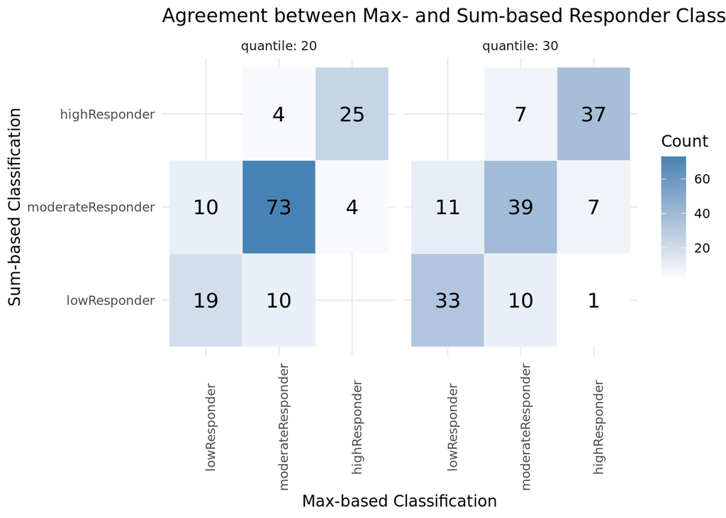

```r
df_compare <- df_responder %>%
  select(Pat_ID, max_d20 = padjMFC_d20, max_d30 = padjMFC_d30) %>%
  left_join(df_responder_sum %>%
              select(Pat_ID, sum_d20 = padjMFC_d20, sum_d30 = padjMFC_d30),
            by = "Pat_ID")

df_heatmap <- df_compare %>%
  pivot_longer(cols = c(max_d20, sum_d20, max_d30, sum_d30),
               names_to = c("method", "quantile"),
               names_pattern = "(max|sum)_d(\\d+)",
               values_to = "responder_class") %>%
  pivot_wider(names_from = method, values_from = responder_class) %>%
  count(quantile, max, sum)

ggplot(df_heatmap, aes(x = max, y = sum, fill = n)) +
  geom_tile(color = "white") +
  geom_text(aes(label = n), color = "black", size = 5) +
  scale_fill_gradient(low = "white", high = "steelblue") +
  facet_wrap(~ quantile, labeller = label_both) +
  labs(
    title = "Agreement between Max- and Sum-based Responder Classifications",
    x = "Max-based Classification",
    y = "Sum-based Classification",
    fill = "Count"
  ) +
  theme_minimal() +
  theme(
    axis.text.x = element_text(angle = 90)
  )
```

## Dense Ranking Method

As an alternative to regression-based approaches, we implemented a **dense ranking strategy** to classify influenza vaccine responders. This method does not rely on parametric modeling and instead evaluates patients based on their relative position within strain-specific response distributions.

### Methodology

- **Step 1: Residual Calculation per Strain**  
  For each strain, a linear regression model was fit:

  $$\text{Fold Change} \sim \text{Baseline Titer}$$

  The **residuals** from these models represent the degree of response after adjusting for baseline levels — a higher residual indicates a better-than-expected response.
- **Step 2: Dense Ranking within Strain**  
  Within each strain, individuals were **ranked by descending residuals**, assigning the same rank to ties. This generates a fair comparison within each strain.
- **Step 3: Summation Across Strains**  
  Residual ranks were summed across all strains for each patient to compute a **total rank score**. Patients were then **ranked again** based on their cumulative performance across all strains.
- **Step 4: Classification by Final Rank**  
  Based on the final ranks, patients were classified into responder categories using 20% and 30% quantile thresholds:
  - **High responders**: Lowest total ranks (top 20% or 30%)
  - **Low responders**: Highest total ranks (bottom 20% or 30%)
  - **Moderate responders**: Middle quantiles

### Considerations

This method avoids assumptions about the distribution of fold changes and **focuses purely on relative performance** across the cohort. However, it may be sensitive to noise in individual strain responses and does not explicitly correct for baseline confounding beyond linear residual adjustment.

It offers a **non-parametric complement** to the previous regression-based methods and may be useful when response distributions are skewed or non-Gaussian.

```r
# 1. Fit residuals per strain (you’ve done this before)
resid_df <- df_fc %>%
  filter(measurement == "hai", metric == "titer") %>%
  group_by(strain) %>%
  nest() %>%
  mutate(
    model = purrr::map(data, ~ lm(fold_change ~ baseline, data = .x)),
    augmented = purrr::map2(model, data, ~ broom::augment(.x, data = .y))
  ) %>%
  unnest(augmented) %>%
  select(Pat_ID, strain, .resid)



# 2. Rank residuals (higher residual = better response)
rank_residuals <- resid_df %>%
  group_by(strain) %>%
  mutate(rank_resid = dense_rank(desc(.resid))) %>%
  ungroup()

# 3. Sum ranks and get final responder rank
df_rank_summary <- rank_residuals %>%
  group_by(Pat_ID) %>%
  summarise(
    total_rank_score = sum(rank_resid, na.rm = TRUE),
    .groups = "drop"
  ) %>%
  mutate(
    final_rank = dense_rank(total_rank_score)
  )


discretize <- c(0.2, 0.3)
responseLabels <- c("lowResponder", "moderateResponder", "highResponder")

df_rank_summary <- df_rank_summary %>%
  mutate(
    padjRank_d20 = case_when(
      final_rank <= quantile(final_rank, 0.2, na.rm = TRUE) ~ "highResponder",
      final_rank >= quantile(final_rank, 0.8, na.rm = TRUE) ~ "lowResponder",
      TRUE ~ "moderateResponder"
    ),
    padjRank_d30 = case_when(
      final_rank <= quantile(final_rank, 0.3, na.rm = TRUE) ~ "highResponder",
      final_rank >= quantile(final_rank, 0.7, na.rm = TRUE) ~ "lowResponder",
      TRUE ~ "moderateResponder"
    )
  )
```

## Beyer-style Correction

Beyer et al. proposed a correction strategy to adjust for the confounding effects of high baseline titers when evaluating influenza vaccine responses. Their method involves working in **log2-transformed space** to linearize titer values and mitigate scale distortions.

### Methodology

- **Step 1: Log2 Transformation**  
  Both baseline and outcome titers are transformed using the binary logarithm (`log2`). This transformation stabilizes variance and simplifies multiplicative relationships into additive ones.
- **Step 2: Raw Log2 Fold Change**  
  A fold change is calculated in the log2-transformed space, defined as:

  $$\text{log2\_fc} = \frac{\log_2(\text{outcome})}{\log_2(\text{baseline})}$$

  Note: This formulation has interpretability issues, so it’s primarily diagnostic at this step.
- **Step 3: Linear Model Correction**  
  A linear model is fitted:

  $$\log_2(\text{outcome}) \sim \log_2(\text{baseline})$$

  The **slope** of this model captures how outcome titers scale with baseline titers. The predicted effect of the baseline is then subtracted to yield a **corrected log2 outcome titer**:

  $$\log_2(\text{outcome\_corrected}) = \log_2(\text{outcome}) - b \cdot
  \log_2(\text{baseline})$$
- **Step 4: Summarization and Classification**  
  Corrected log2 outcome titers are **summed across all strains** for each patient. Based on the distribution, patients are classified into:
  - **High responders**: Top 20% / 30%
  - **Low responders**: Bottom 20% / 30%
  - **Moderate responders**: Middle range

This approach enables fair comparison of vaccine-induced responses while controlling for baseline immunity.

```r
# transform titers to binary logarithm.

df_fc <- df_fc %>%
    mutate(
    log2_baseline = log2(baseline),
    log2_outcome = log2(outcome)
  )
```

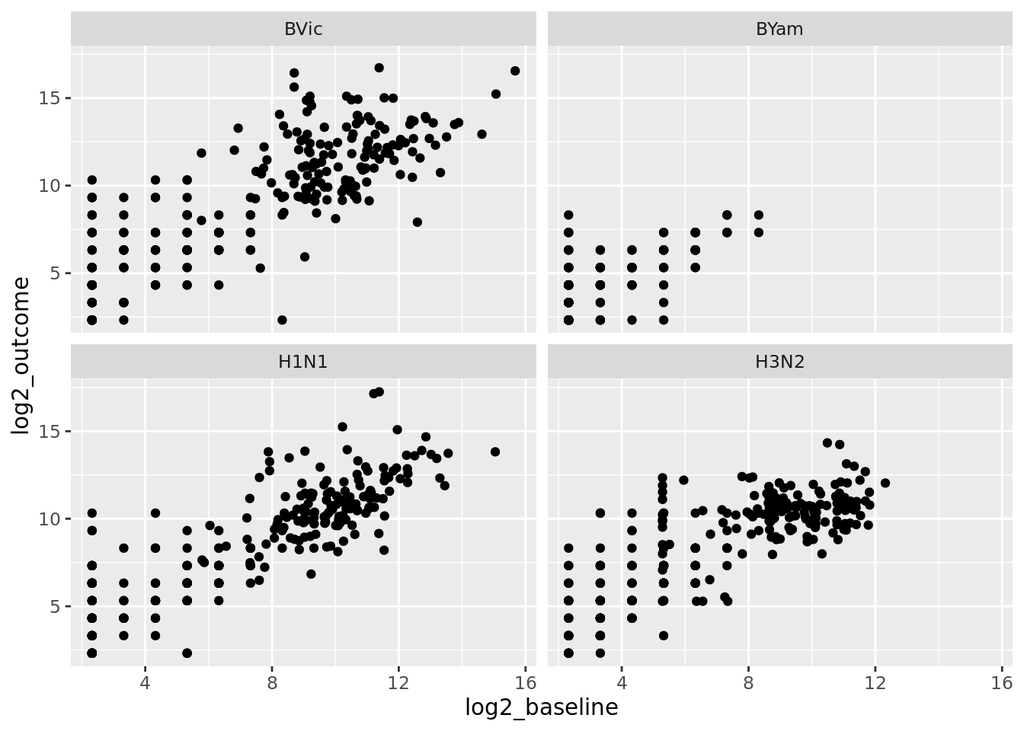

```r
df_fc %>%
  ggplot(aes(x=log2_baseline, y=log2_outcome)) +
  geom_point() +
  facet_wrap(~strain)
```

```r
df_fc <- df_fc %>%
    mutate(
    log2_fc = log2_outcome / log2_baseline  )
```

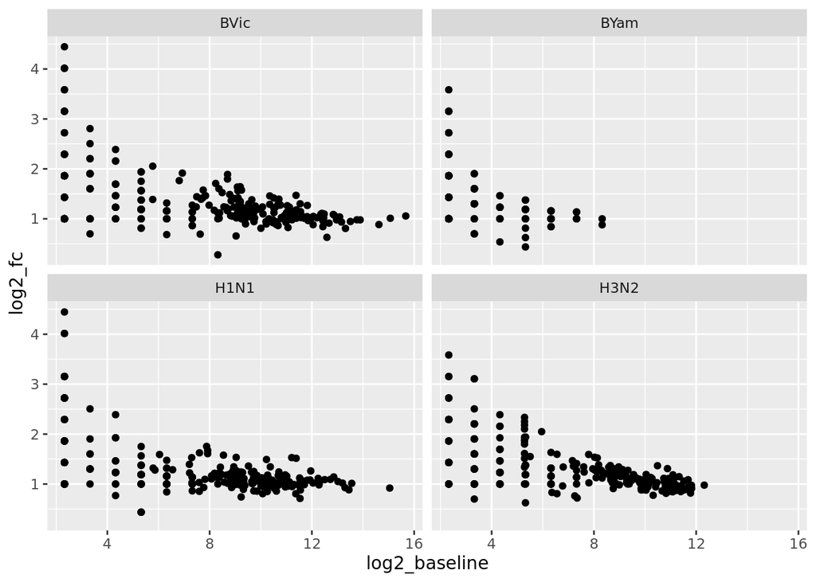

```r
df_fc %>%
  ggplot(aes(x=log2_baseline, y=log2_fc)) +
  geom_point() +
  facet_wrap(~strain)
```

Now we fit alinear model and recalculate the fold-change

```r
model <- lm(log2_outcome ~ log2_baseline, data = df_fc)

# Extract slope (b)
b <- coef(model)["log2_baseline"]

# Calculate corrected post-vaccination log2 titer
df_fc <- df_fc %>%
  mutate(
    log2_outcome_corrected = log2_outcome - b * log2_baseline
  )
```

Now we can redo the plot to see if the distribution is better:

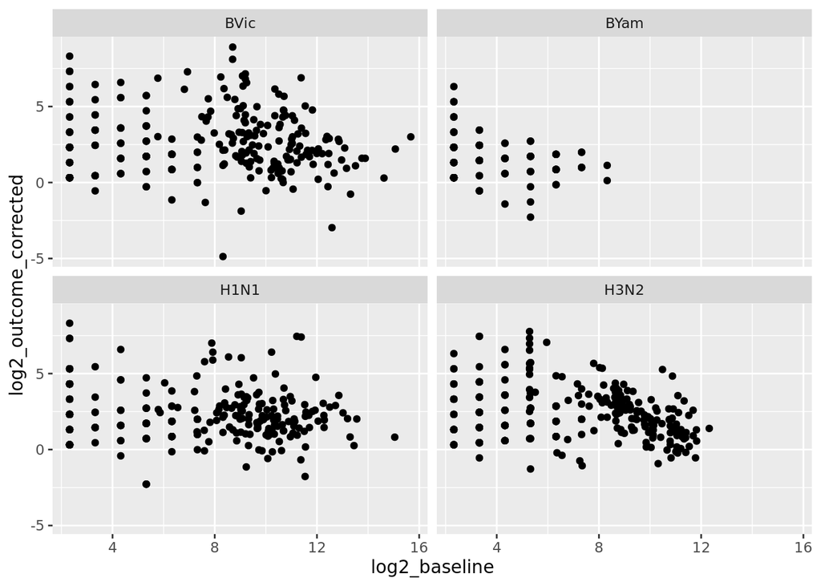

```r
df_fc %>%
  ggplot(aes(x=log2_baseline, y=log2_outcome_corrected)) +
  geom_point() +
  facet_wrap(~strain)
```

This makes sense, we don’t have the skewed distriution anymore. Therefore, we can now compare the outcome titers directly.

However, we need to sum them up first:

```r
df_beyer <- df_fc %>%
  group_by(Pat_ID) %>%
  summarise(log2_outcome_corrected = sum(log2_outcome_corrected))
```

### Responder Classification Based on Corrected Outcome Titers

```r
discretize <- c(0.2, 0.3)
responseLabels <- c("lowResponder", "moderateResponder", "highResponder")


for (dis in discretize) {
  q_low <- quantile(df_beyer$log2_outcome_corrected, dis, na.rm = TRUE)
  q_high <- quantile(df_beyer$log2_outcome_corrected, 1 - dis, na.rm = TRUE)

  df_beyer <- df_beyer %>%
    mutate(!!paste0("padjBeyer_d", dis * 100) := factor(case_when(
      is.na(log2_outcome_corrected) ~ NA_character_,
      log2_outcome_corrected <= q_low ~ responseLabels[1],
      log2_outcome_corrected >= q_high ~ responseLabels[3],
      TRUE ~ responseLabels[2]
    ), levels = responseLabels))
}
```

## Summary

To compare the classification results across all four methods, we consolidated the responder labels into a unified matrix for visualization. Each method was applied at two quantile thresholds: **20%** and **30%**, resulting in eight distinct classification outputs per patient.

### Method Overview

The following methods were included in the comparison:

- **Max-based regression residuals** (`padjMax`)
- **Sum-based regression residuals** (`padjSum`)
- **Dense rank-based method** (`padjRank`)
- **Beyer-style correction with summed log2 outcomes** (`padjBeyer`)

### Approach

1. All responder classifications (`lowResponder`, `moderateResponder`, `highResponder`) were recoded numerically:
   - `0` = lowResponder
   - `1` = moderateResponder
   - `2` = highResponder
2. A heatmap matrix was constructed where:
   - **Rows** represent each method at a given quantile (e.g., `Max_20`, `Sum_30`)
   - **Columns** represent individual patients
   - **Cell colors** represent responder class
3. The heatmaps were split by quantile threshold (20% and 30%) and clustered to reveal patterns of agreement and disagreement.

```r
df_combined <- df_responder %>%
  select(Pat_ID, padjMax_d20 = padjMFC_d20, padjMax_d30 = padjMFC_d30) %>%
  left_join(df_responder_sum %>% select(Pat_ID, padjSum_d20 = padjMFC_d20, padjSum_d30 = padjMFC_d30), by = "Pat_ID") %>%
  left_join(df_rank_summary %>% select(Pat_ID, padjRank_d20, padjRank_d30), by = "Pat_ID") %>%
  left_join(df_beyer %>% select(Pat_ID, padjBeyer_d20, padjBeyer_d30 ))
```

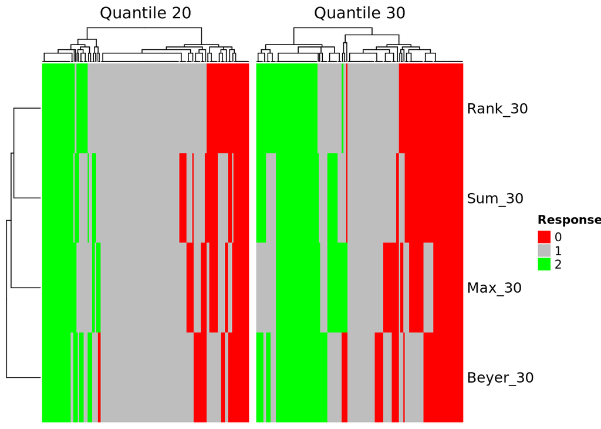

```r
df_long_heatmap <- df_combined %>%
  pivot_longer(
    cols = starts_with("padj"),
    names_to = c("method", "quantile"),
    names_pattern = "padj(.*)_d(\\d+)",
    values_to = "response"
  )

df_long_heatmap <- df_long_heatmap %>%
  mutate(
    method_quant = paste0(method, "_", quantile),
    response_num = recode(response,
      "lowResponder" = 0,
      "moderateResponder" = 1,
      "highResponder" = 2
    )
  )

# 2. Pivot to wide and ensure correct types
heatmat <- df_long_heatmap %>%
  select(Pat_ID, method_quant, response_num) %>%
  pivot_wider(names_from = Pat_ID, values_from = response_num) %>%
  mutate(across(where(is.list), ~ map_dbl(., ~ ifelse(length(.) == 0, NA_real_, .)))) %>%  # flatten any lists
  column_to_rownames("method_quant") %>%
  as.matrix()

# 3. Now you can safely draw the heatmaps
heatmap_20 <- Heatmap(
  heatmat[grepl("_20$", rownames(heatmat)), , drop = FALSE],
  name = "Response",
  col = c("0" = "red", "1" = "gray", "2" = "green"),
  cluster_columns = TRUE,
  cluster_rows = TRUE,
  show_column_names = FALSE,
  column_title = "Quantile 20",
  na_col = "white"
)

heatmap_30 <- Heatmap(
  heatmat[grepl("_30$", rownames(heatmat)), , drop = FALSE],
  name = "Response",
  col = c("0" = "red", "1" = "gray", "2" = "green"),
  cluster_columns = TRUE,
  cluster_rows = TRUE,
  show_column_names = FALSE,
  column_title = "Quantile 30",
  na_col = "white"
)

# Combine
heatmap_20 + heatmap_30
```

## Cross-Method Responder Agreement

To assess the **consistency** of patient classification across all four methods, we performed a comprehensive agreement analysis.

### Methodology

1. Each patient had up to four labels (one from each method) at two quantile thresholds (20% and 30%).
2. We defined two levels of agreement:
   - **Full agreement**: All four methods assign the same responder label (`highResponder` or `lowResponder`)
   - **Partial agreement**: At least **three out of four methods** agree on the same label
3. Patients with consistent classifications were identified and summarized by group.

### Agreement Summary

```r
summarize_agreement_full_and_partial <- function(df, suffix) {
  # Select relevant columns
  df_sel <- df %>%
    select(Pat_ID, ends_with(suffix)) %>%
    select(-Pat_ID)

  # Count agreement and label
  agreement_info <- df_sel %>%
    apply(1, function(x) {
      tab <- table(x)
      max_agree <- max(tab)
      label <- names(tab)[which.max(tab)]
      return(c(max_agree = max_agree, consensus_label = label))
    }) %>%
    t() %>%
    as.data.frame() %>%
    mutate(
      max_agree = as.integer(max_agree),
      consensus_label = as.character(consensus_label)
    )

  # Filter to relevant responder types
  agreement_info <- agreement_info %>%
    filter(consensus_label %in% c("lowResponder", "highResponder"))

  # Count full (4/4) agreement
  full_agreement <- agreement_info %>%
    filter(max_agree == 4) %>%
    count(agreement_type = "all methods agree",
          quantile = suffix,
          consensus_label,
          name = "n")

  # Count partial (≥3/4) agreement
  partial_agreement <- agreement_info %>%
    filter(max_agree >= 3) %>%
    count(agreement_type = "three or more methods agree",
          quantile = suffix,
          consensus_label,
          name = "n")

  bind_rows(full_agreement, partial_agreement)
}

# Apply to both quantiles
summary_d20 <- summarize_agreement_full_and_partial(df_combined, "d20")
summary_d30 <- summarize_agreement_full_and_partial(df_combined, "d30")

# Combine
final_summary <- bind_rows(summary_d20, summary_d30)

# Output nicely sorted
final_summary <- final_summary %>%
  arrange(quantile, agreement_type, consensus_label)

kableExtra::kable(final_summary) %>%
  kable_styling()
```

| agreement_type | quantile | consensus_label | n |
| --- | --- | --- | --- |
| all methods agree | d20 | highResponder | 20 |
| all methods agree | d20 | lowResponder | 11 |
| three or more methods agree | d20 | highResponder | 25 |
| three or more methods agree | d20 | lowResponder | 22 |
| all methods agree | d30 | highResponder | 29 |
| all methods agree | d30 | lowResponder | 21 |
| three or more methods agree | d30 | highResponder | 35 |
| three or more methods agree | d30 | lowResponder | 41 |

### Group-specific Agreement Table

To understand if consistent responder patterns were group-dependent, we merged patient metadata and generated stratified summaries by `pat_group`.

```r
pat_metadata <- df_fc %>%
  select(Pat_ID, pat_group) %>%
  distinct()

df_combined <- df_combined %>%
  left_join(pat_metadata)
df_summary <- df_combined %>%
  pivot_longer(
    -c("Pat_ID", "pat_group"), names_to = "analysis", values_to = "outcome"
  ) %>%
  separate(analysis, into = c("analysis", "quantile"), sep = "_")


df_summary <- df_summary %>%
  group_by(Pat_ID, outcome, quantile, pat_group) %>%
  summarise(count = n(), .groups = "drop") %>%
  tidyr::pivot_wider(
    names_from = outcome,
    values_from = count,
    values_fill = 0
  ) %>%
  mutate(all_high = case_when(
             highResponder == 4 ~ TRUE,
             .default = FALSE),
         gt_three_high = case_when(
           highResponder >= 3 ~ TRUE,
           .default = FALSE
         ),
         all_low = case_when(
           lowResponder == 4 ~ TRUE,
           .default = FALSE
         ),
         gt_three_low = case_when(
           lowResponder >= 3 ~ TRUE,
           .default = FALSE
         ))
```

### quantile 20: Table of responder categorisation where all methods agree

```r
df_table <- df_summary %>%
  filter(quantile == "d20",
         all_high | all_low) %>%
  select(pat_group, Pat_ID, all_high, all_low) %>%
  group_by(pat_group) %>%
  summarise(
    all_high_true = sum(all_high, na.rm = TRUE),
    all_low_true = sum(all_low, na.rm = TRUE),
    .groups = "drop"
  ) %>%
    add_row(
    pat_group = "Total",
    all_high_true = sum(.$all_high_true),
    all_low_true = sum(.$all_low_true)
  )

kable(df_table) %>%
  kable_styling() %>%
    row_spec(nrow(df_table), bold = TRUE)
```

| pat_group | all_high_true | all_low_true |
| --- | --- | --- |
| Control | 3 | 3 |
| HIV | 4 | 2 |
| MS | 2 | 2 |
| ONK | 3 | 4 |
| RH | 8 | 0 |
| Total | 20 | 11 |

### quantile 30: Table of responder categorisation where all methods agree

```r
df_table <- df_summary %>%
  filter(quantile == "d30",
         all_high | all_low) %>%
  select(pat_group, Pat_ID, all_high, all_low) %>%
  group_by(pat_group) %>%
  summarise(
    all_high_true = sum(all_high, na.rm = TRUE),
    all_low_true = sum(all_low, na.rm = TRUE),
    .groups = "drop"
  ) %>%
    add_row(
    pat_group = "Total",
    all_high_true = sum(.$all_high_true),
    all_low_true = sum(.$all_low_true)
  )

kable(df_table) %>%
  kable_styling() %>%
    row_spec(nrow(df_table), bold = TRUE)
```

| pat_group | all_high_true | all_low_true |
| --- | --- | --- |
| Control | 4 | 6 |
| HIV | 8 | 4 |
| MS | 4 | 2 |
| ONK | 4 | 7 |
| RH | 9 | 2 |
| Total | 29 | 21 |

### quantile 20: Table of responder categorisation where three or more methods agree

```r
df_table <- df_summary %>%
  filter(quantile == "d20",
         gt_three_high | gt_three_low) %>%
  select(pat_group, Pat_ID, gt_three_high, gt_three_low) %>%
  group_by(pat_group) %>%
  summarise(
    gt_three_high = sum(gt_three_high, na.rm = TRUE),
    gt_three_low = sum(gt_three_low, na.rm = TRUE),
    .groups = "drop"
  ) %>%
    add_row(
    pat_group = "Total",
    gt_three_high = sum(.$gt_three_high),
    gt_three_low = sum(.$gt_three_low)
  )

kable(df_table) %>%
  kable_styling() %>%
    row_spec(nrow(df_table), bold = TRUE)
```

| pat_group | gt_three_high | gt_three_low |
| --- | --- | --- |
| Control | 4 | 4 |
| HIV | 5 | 5 |
| MS | 2 | 5 |
| ONK | 4 | 8 |
| RH | 10 | 0 |
| Total | 25 | 22 |

### quantile 30: Table of responder categorisation where three or more methods agree

```r
df_table <- df_summary %>%
  filter(quantile == "d30",
         gt_three_high | gt_three_low) %>%
  select(pat_group, Pat_ID, gt_three_high, gt_three_low) %>%
  group_by(pat_group) %>%
  summarise(
    gt_three_high = sum(gt_three_high, na.rm = TRUE),
    gt_three_low = sum(gt_three_low, na.rm = TRUE),
    .groups = "drop"
  ) %>%
    add_row(
    pat_group = "Total",
    gt_three_high = sum(.$gt_three_high),
    gt_three_low = sum(.$gt_three_low)
  )

kable(df_table) %>%
  kable_styling() %>%
    row_spec(nrow(df_table), bold = TRUE)
```

[output not shown]

## Conclusion

We have decided to go for the approach to include all samples where three or more analyses have agreed. We will take the quantile 30 as a start.

```r
## Experimental desgin file
df <- df_summary %>%
  filter(quantile == "d30",
         gt_three_high | gt_three_low) %>%
  select(Pat_ID, pat_group)

write.csv(df, "q30_samples.csv", row.names = F, quote = F)
```